# Frozen-family check: FB vs MR correspondence under non-regenerating cuts

```r
library(forestsearch)
library(survival)
library(data.table)
library(doFuture)
library(kableExtra)

timings <- list()
print(getwd())
```

```
[1] "/Users/larryleon/Documents/GitHub/forestsearch/quarto/applications/gbsg"
```

```r
# Guo & He comparator: sourced, not installed (as in the headline analysis).
gh_dir <- Sys.getenv("GH_DIR", unset = "../../../quarto/GuoHe")
source(file.path(gh_dir, "guohe_algorithm3.R"))
source(file.path(gh_dir, "fs_to_guohe.R"))
```

```r
n_cores <- max(1L, floor(0.80 * parallel::detectCores(logical = FALSE)))
NB         <- 20L     # full-bootstrap resamples, matching the headline run
gate_draws <- 500L     # MR multiplier draws
GH_B       <- 20L     # Guo & He pair-bootstrap resamples
GH_r       <- 0.03      # Guo & He tuning parameter
GH_PARALLEL <- .Platform$OS.type == "unix"   # forked GH bootstrap where available
run_loo    <- TRUE      # leave-one-out (N-fold) honest out-of-sample subgroup estimate
timings$loo <- NA_real_
# Sequential-vs-multisession A/B on the LOO fold loop (@sec-loo-parallel).
run_loo_par <- TRUE     # repeat the LOO with a parallel fold loop
# Fold-loop workers: 80% of physical cores (the same rule as n_cores above), so
# the A/B adapts to whichever machine renders this -- Mac or the 127-core box.
# There is no nested parallelism to guard against: forestsearch_Kfold() pins each
# fold's inner forestsearch() refit to plan = "sequential", workers = 1, so these
# workers are the ONLY ones in play. Replace with a fixed integer to pin it.
loo_workers <- n_cores
loo_fresh   <- TRUE     # bypass the LOO cache so BOTH runs are timed this render
timings$loo_par <- NA_real_
run_cv_kfold <- FALSE    # repeated 10-fold cross-validation (stability diagnostics)
Ksims       <- 50L      # repeated 10-fold partitions (>= 50 for production)
timings$kfold <- NA_real_
cat("Using", n_cores, "workers (80% of",
    parallel::detectCores(logical = FALSE), "physical cores);",
    "LOO fold-loop workers:", loo_workers, "\n")
```

```
Using 11 workers (80% of 14 physical cores); LOO fold-loop workers: 11
```

```r
df.analysis <- gbsg
df.analysis <- within(df.analysis, {
  id <- seq_len(nrow(df.analysis))
  time_months <- rfstime / 30.4375
  grade3 <- ifelse(grade == "3", 1, 0)
})

# The forced cuts are computed ONCE on the observed data and hard-coded as
# fixed-threshold expressions, so the bootstrap replay cannot move them.
med <- sapply(c("age", "size", "nodes", "pgr", "er"),
              function(v) stats::median(df.analysis[[v]]))
frozen_cuts <- c(
  sprintf("age <= %g",   med[["age"]]),     # observed median
  sprintf("size <= %g",  med[["size"]]),
  sprintf("nodes <= %g", med[["nodes"]]),
  sprintf("pgr <= %g",   med[["pgr"]]),
  sprintf("er <= %g",    med[["er"]]),
  "er <= 0",                                 # receptor-negative (clinical)
  "pgr <= 0"
)
cat("Frozen cuts (fixed thresholds, replayed verbatim under bootstrap):\n")
```

```
Frozen cuts (fixed thresholds, replayed verbatim under bootstrap):
```

```r
cat(paste0("  ", frozen_cuts), sep = "\n")
```

```
  age <= 53
  size <= 25
  nodes <= 3
  pgr <= 32.5
  er <= 36
  er <= 0
  pgr <= 0
```

```r
# CATEGORICAL factors only in confounders.name: the continuous factors are
# DROPPED so forestsearch never auto-cuts (and never quantile-recomputes) them.
confounders.name <- c("meno", "grade3")

outcome.name <- "time_months"
event.name   <- "status"
id.name      <- "id"
treat.name   <- "hormon"
```

## 1 Frozen-family fit

Every continuous factor is represented only by fixed median cuts (plus the receptor-negative cuts); the continuous factors themselves are excluded from the confounder set, and `conf.cont_jcuts` is not used. The candidate family is therefore fully determined by the fixed cuts and cannot regenerate under bootstrap resampling.

```
[forestsearch] Subgroup Identification Configuration
  Outcome type:   survival (Cox PH)
  Effect measure: HR (hazard ratio)
  Scale:          log (ratio)

  Screening:      HR >= 1.25  (log: 0.2231)
  Consistency:    HR >= 1.00  (log: 0.0000)
  Consistency rate threshold: 0%

  Interpretation:
    Candidates: subgroup hazard ratio >= 1.25
    Splits:     each split HR >= 1.00
```

```
  Search Alignment Diagnostic
```

```
  Outcome:    time_months (survival)
```

```
  Treatment:  hormon
```

```
  Measure:    Hazard Ratio (HR)
```

```
  ForestSearch searches for:
    Subgroups where hormon increases the event hazard
    (HR >= threshold in the candidate subgroup)
```

```
  Thresholds:
    Screening: HR >= 1.250 in the candidate subgroup
    Consistency: HR >= 1.000 in each bootstrap split
```

```
  Variable screening:
```

```
    LASSO: LASSO screening: DISABLED
```

```
    GRF:   DISABLED
```

```
  No alignment concerns detected.
```

```
Forced confounders: age <= 53, size <= 25, nodes <= 3, pgr <= 32.5, er <= 36, er <= 0, pgr <= 0
Candidate factors: 9
[1] "meno"        "grade3"      "age <= 53"   "size <= 25"  "nodes <= 3"
[6] "pgr <= 32.5" "er <= 36"    "er <= 0"     "pgr <= 0"
Number of possible configurations (<= maxk): maxk = 2 , # combinations = 171
Per-arm events criteria: control >= 10, treatment >= 10
Sample size criteria: n >= 60
Subgroup search completed in 0.01 minutes

--- Filtering Summary ---
  Combinations evaluated: 171
  Passed variance check: 160
  Passed prevalence (>= 0 ): 160
  Passed redundancy check: 158
  Passed events counts (d0>= 10, d1>= 10): 128
  Passed sample size (n>= 60 ): 118
  Cox model fit successfully: 118
  Passed effect threshold (effect >= 1.2500): 118
-------------------------

Found 118 subgroup candidate(s)
# of candidate subgroups (meeting all criteria) = 118
# of unique initial candidates: 116
# Restricting to top stop_Kgroups = Inf
# of candidates to evaluate: 116

==============================================================================================================
CANDIDATE EVALUATION PREVIEW (pre-consistency) (sg_focus = "maxeff", selection_rule = "neighborhood")
==============================================================================================================
Rank  HR      N      E     K    OF  Subgroup
--------------------------------------------------------------------------------------------------------------
   1   2.222     75    41    2  *   {er <= 0} & {pgr <= 32.5}
   2   1.951     82    45    1  *   {er <= 0}
   3   1.381     77    46    2  -   {er <= 36} & {pgr <= 0}
   4   1.274     88    53    1  *   {pgr <= 0}
   5   1.150    115    58    2  *   {grade3} & {er <= 36}
   6   1.133    138    73    2  *   {pgr <= 32.5} & !{meno}
   7   1.129    170   101    2  *   !{size <= 25} & {pgr <= 32.5}
   8   1.087     92    47    2  -   !{size <= 25} & {grade3}
   9   1.053    127    68    2  -   {grade3} & {pgr <= 32.5}
  10   1.045    163    87    2  -   !{size <= 25} & {er <= 36}
... 106 more candidates not shown (max_print = 10).
--------------------------------------------------------------------------------------------------------------
To evaluate: 116   On frontier: 17
Legend: OF = on Pareto frontier.
==============================================================================================================

116 subgroups passed consistency threshold
```

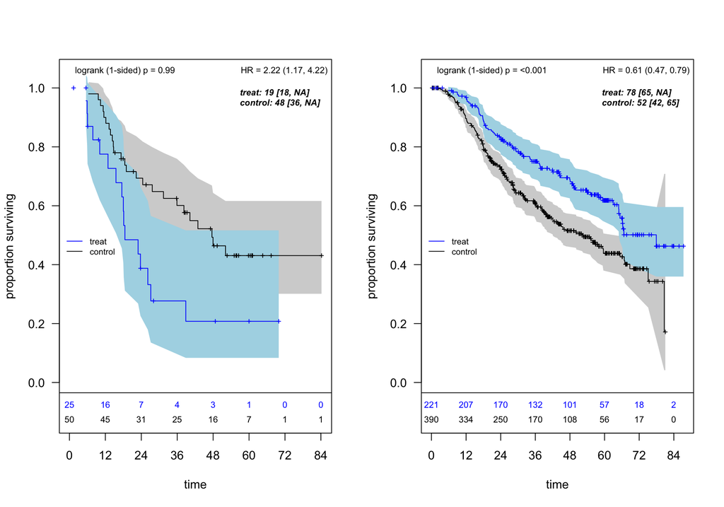

```
*** Subgroup found: {er <= 0} {pgr <= 32.5}
% consistency criteria met= 0.99
SG focus = maxeff

==============================================================================================================
CANDIDATE EVALUATION SUMMARY  (sg_focus = "maxeff", selection_rule = "neighborhood")
==============================================================================================================
Rank  HR      N      E     K    OF  S  Subgroup
--------------------------------------------------------------------------------------------------------------
   1   2.222     75    41    2  *   *  {er <= 0} & {pgr <= 32.5}
   2   1.951     82    45    1  *   -  {er <= 0}
   3   1.381     77    46    2  -   -  {er <= 36} & {pgr <= 0}
   4   1.274     88    53    1  *   -  {pgr <= 0}
   5   1.150    115    58    2  *   -  {grade3} & {er <= 36}
   6   1.133    138    73    2  *   -  {pgr <= 32.5} & !{meno}
   7   1.129    170   101    2  *   -  !{size <= 25} & {pgr <= 32.5}
   8   1.087     92    47    2  -   -  !{size <= 25} & {grade3}
   9   1.053    127    68    2  -   -  {grade3} & {pgr <= 32.5}
  10   1.045    163    87    2  -   -  !{size <= 25} & {er <= 36}
... 106 more candidates not shown (max_print = 10).
--------------------------------------------------------------------------------------------------------------
Evaluated: 116   Passed: 116   On frontier: 17   Selected: m=1
Selected subgroup Pcons (consistency probability): 0.990
Legend: OF = on Pareto frontier; S = selected.
==============================================================================================================

Seconds and minutes forestsearch overall = 0.63 0.0105
Consistency algorithm used: fixed
Subgroup identified: {er <= 0} & {pgr <= 32.5}
De-biased gate: HR = 1.712 (gate point 1.00) -> consistent with harm
```

```r
t0 <- proc.time()

fs <- forestsearch(
  df.analysis,
  outcome.name       = outcome.name,
  event.name         = event.name,
  treat.name         = treat.name,
  id.name            = id.name,
  confounders.name   = confounders.name,   # categorical only
  is.RCT             = TRUE,
  seedit             = 8316951,
  est.scale          = "hr",
  use_lasso          = FALSE,
  use_grf            = FALSE,
  use_dina           = FALSE,
  conf_force         = frozen_cuts,        # all cuts fixed
  # conf.cont_jcuts intentionally OMITTED -- no quantile cuts
  collapse_cuts      = TRUE,
  subgroup_method    = "consistency",
  sg_focus           = "maxeff",
  n.min              = 60, d0.min = 10, d1.min = 10, maxk = 2,
  debias_gate        = TRUE,
  debias_gate_args   = list(draws = gate_draws),
  consistency_method = "resample",
  fs.splits          = 1000, stop_threshold = 0.95,
  use_twostage       = TRUE, max.minutes = 3,
  show_candidate_summary = TRUE, details = TRUE, quiet = FALSE,
  plot.sg            = TRUE,
  parallel_args = list(plan = "multisession", workers = n_cores,
                       show_message = TRUE)
)
```

```r
plan("sequential")
timings$fit <- (proc.time() - t0)[["elapsed"]]
stopifnot(!is.null(fs$sg.harm))
cat("\nSelected subgroup:", paste(fs$sg.harm, collapse = " & "),
    "  |  fit", round(timings$fit / 60, 1), "min\n")
```

```
Selected subgroup: {er <= 0} & {pgr <= 32.5}   |  fit 0 min
```

### 1.1 Gate 0 – confirm the family is actually frozen

The whole check is void if any candidate cut is quantile-derived (hence regenerating). Verify that the realized candidate family contains only the fixed cuts: every cut label must correspond to one of the forced expressions or a categorical factor level, and no continuous factor may appear as an auto-derived cut. This is a hard gate – if it fails, stop; the comparison below is not interpretable.

```r
fam <- as.data.frame(fs$grp.consistency$out_sg$result)
mcols <- grep("^M\\.[0-9]+$", names(fam), value = TRUE)
labels <- unique(unlist(lapply(mcols, function(cn) fam[[cn]])))
labels <- labels[nzchar(labels)]

# Normalize a family cut label ("{er <= 0}", "!{age <= 53}") to its inner form.
norm_lab <- function(x) {
  x <- sub("^!", "", trimws(x))
  trimws(sub("^\\{", "", sub("\\}$", "", x)))
}
inner <- sort(unique(norm_lab(labels)))

# Allowed inner forms: the forced cuts, plus categorical factor cuts on
# meno / grade3 (which forestsearch may encode as "meno <= 0" / bare levels).
allowed_fixed <- frozen_cuts
cat("Distinct candidate cut forms in the realized family:\n")
```

```
Distinct candidate cut forms in the realized family:
```

```r
cat(paste0("  ", inner), sep = "\n")
```

```
  age <= 53
  er <= 0
  er <= 36
  grade3
  meno
  nodes <= 3
  pgr <= 0
  pgr <= 32.5
  size <= 25
```

```r
# Flag any cut on a continuous factor that is NOT one of the fixed thresholds.
cont_vars <- c("age", "size", "nodes", "pgr", "er")
offending <- inner[
  vapply(inner, function(s) {
    v <- sub("\\s*(<=|>=|<|>|==).*$", "", s)
    v <- trimws(v)
    (v %in% cont_vars) && !(s %in% trimws(sub("\\s+", " ", allowed_fixed)))
  }, logical(1))
]

if (length(offending)) {
  stop("GATE 0 FAILED -- continuous-factor cuts not in the fixed set are ",
       "present (family is NOT frozen): ",
       paste(offending, collapse = "; "))
}
cat("\nGATE 0 PASS -- every continuous-factor cut is a fixed threshold; ",
    "the family cannot regenerate under bootstrap.\n", sep = "")
```

```
GATE 0 PASS -- every continuous-factor cut is a fixed threshold; the family cannot regenerate under bootstrap.
```

## 2 Full bootstrap (FB)

```r
t0 <- proc.time()
fs_bc <- forestsearch_bootstrap_dofuture(
  fs.est   = fs, nb_boots = NB, show_three = FALSE, details = FALSE,
  parallel_args = list(plan = "multisession", workers = n_cores,
                       show_message = TRUE)
)
```

```
Bootstrap parallel config: Using user-provided settings
```

```
System max cores available: 14
```

```
Bootstrap will use: 11 workers with 'multisession' plan
```

```
Parallel plan: multisession with 11 workers.
```

```
Bootstrap iteration 1/20
```

```
Bootstrap iteration 10/20
```

```
Bootstrap iteration 20/20
```

```r
plan("sequential")
timings$fb <- (proc.time() - t0)[["elapsed"]]
cat("FB completed in", round(timings$fb / 60, 1), "min\n")
```

```
FB completed in 0.1 min
```

## 3 Multiplier resampling (MR)

```r
g <- fs$debias_gate
stopifnot(!is.null(g))
timings$mr <- g$timing_seconds
cat("MR gate:", round(timings$mr, 2), "s over",
    format(gate_draws, big.mark = ","), "draws\n")
```

```
MR gate: 0.01 s over 500 draws
```

## 4 Guo & He (GH)

The adapter exports the frozen candidate family as membership columns and runs Guo & He Algorithm 3 on the same selected subgroup, asserting membership integrity against `fit$grp.consistency$sg.harm.id` before the estimator runs. The frozen family is coarser than the headline maxeff family (about 116 candidates versus ~1340), which remains well within the range where the argmax de-biasing is meaningful.

```r
t0 <- proc.time()
gh <- fs_to_guohe(
  fit       = fs,
  time      = "time_months", event = "status", treatment = "hormon",
  B         = GH_B, r = GH_r, level = 0.05, seed = 8316951,
  parallel  = GH_PARALLEL, verify = TRUE
)
timings$gh <- (proc.time() - t0)[["elapsed"]]
cat("GH family size:", length(gh$export$candidates),
    " | selected:", gh$selected,
    " | GH", round(timings$gh / 60, 1), "min\n")
```

```
GH family size: 116  | selected: sg_0001  | GH 0 min
```

```r
cat(sprintf("GH  naive HR %.3f  debiased HR %.3f  lower bound %.3f\n",
            gh$naive_hr, gh$debiased_hr, gh$bound_hr))
```

```
GH  naive HR 2.222  debiased HR 1.329  lower bound 0.837
```

## 5 Repeated 10-fold cross-validation (stability diagnostics)

Repeated 10-fold cross-validation partitions the data into ten folds, refits the selection on each nine-fold training set, and records which subgroup is identified – repeated over `Ksims` random partitions. It is a **stability diagnostic on the subgroup *definition***: across `Ksims` × 10 training splits, does the maxeff argmax converge on a single dominant subgroup, or does the selection wander with the particular split? This is `forestsearch_tenfold()`; because the search is data-adjacent, the recovered-subgroup distribution is the quantity of interest.

This is a pure maxeff, fixed-family analysis (no GRF, DINA, or LASSO screens), so the GRF-specific fold diagnostics are omitted; the universal ones – identified- subgroup distribution, selected-candidate consistency, per-fold numerics, and agreement with the full-data selection – are reported.

```r
cat("> **10-fold CV skipped.** Set `run_cv_kfold <- TRUE` in the",
    "configuration to enable.\n")
```

> **10-fold CV skipped.** Set `run_cv_kfold <- TRUE` in the configuration to enable.

```r
t0 <- proc.time()
fs_kfold <- forestsearch_tenfold(
  fs.est  = fs,
  sims    = Ksims,
  Kfolds  = 10,
  details = FALSE,
  parallel_args = list(plan = "multisession", workers = n_cores,
                       show_message = FALSE)
)
plan("sequential")
timings$kfold <- (proc.time() - t0)[["elapsed"]]
cat("10-fold CV:", Ksims, "x 10 partitions in",
    round(timings$kfold / 60, 1), "min\n")
metrics_tables <- cv_metrics_tables(fs_kfold)
metrics_tables
```

### 5.1 Diagnostic tabulations

`summarize_cv_results()` consolidates the per-fold record into diagnostic tables. For this maxeff fixed-family analysis the meaningful (non-GRF) diagnostics are: the distribution of identified subgroups across resamples, the consistency of the selected candidates, the per-fold numeric summary, and agreement with the full-data selection.

```r
cv_diag <- summarize_cv_results(
  cv_output    = fs_kfold,
  original_sg  = fs$sg.harm,
  top_n        = 10L,
  create_plots = TRUE
)
```

**Which subgroups emerged across resamples?** The identification summary shows the distribution of selected subgroups across all 50 × 10 sim × fold pairs. A single dominant subgroup with high share indicates the maxeff argmax converges on a stable selection; a long tail indicates the selection is sensitive to the training split.

```r
cv_diag$identification_summary
```

**How confidently were the successful identifications made?** Among folds that identified a subgroup, the `pconsistency_distribution` shows where the selected candidate’s consistency probability (`Pcons`) landed. (Under maxeff no consistency threshold is applied at selection, so this is descriptive of the selected argmax, not a gate.)

```r
cv_diag$pconsistency_distribution
```

**How do the numeric fold-level diagnostics summarize?** The `fold_numeric_summary` tabulates median / IQR / range for each numeric fold-level column: fold size (`n_test`), training-fold HR of the selected subgroup (`training_fs_hr`, in-sample and optimistically biased – for diagnostic comparison only), and candidate count (`n_candidates_evaluated`).

```r
cv_diag$fold_numeric_summary
```

**Agreement with the full-data analysis.** How often does a training fold reproduce the original full-data subgroup exactly, or share a factor with it?

```r
cv_diag$original_agreement
```

**Identified-subgroup distribution (plot).** The bar chart of the top identified subgroups across the 50 × 10 partitions visualizes the stability of the maxeff selection: a dominant bar is a stable definition, a flat spread is an unstable one.

```r
if (!is.null(cv_diag$plots) && !is.null(cv_diag$plots$identification)) {
  cv_diag$plots$identification
}
```

## 6 Leave-one-out (honest out-of-sample estimate)

Leave-one-out re-runs the entire selection on each hold-out of one subject and predicts the held-out subject’s subgroup membership from its covariates. It is an out-of-sample **stability check on the subgroup *definition***, not a de-biasing correction of the *effect*: it asks whether the same subgroup is recovered when no subject informs its own label. This is `forestsearch_Kfold()` at N-fold (`Kfolds = nrow(df)`), the same leave-one-out analysis carried in the multimethod document, applied to the frozen-family fit. Both the recovered definition (how often, and which) and its out-of-sample hazard ratio are reported below; see the interpretation callout for why, here, the out-of-sample HR equals Naive by construction.

Note this is the heaviest step: N-fold means one full forest search per subject (here 686 re-runs). It is tractable on the small frozen family but is the long pole; on the analysis box, not the sandbox.

```r
cat("Leave-one-out skipped (run_loo = FALSE).",
    "Set run_loo <- TRUE in parallel-setup to run it.\n")
```

```r
# Leave-one-out (N-fold) is the long pole -- one full forest search per subject
# (686 re-runs). If a precomputed cv_out is available (LOO_CACHE env var, else
# the default path in gh_dir) load it; otherwise run the N-fold search and cache
# it for re-renders. Sequential execution is used for reproducibility.
loo_cache <- Sys.getenv("LOO_CACHE",
                        unset = file.path(gh_dir, "cv_out_frozen_family.rds"))
if (file.exists(loo_cache) && !isTRUE(loo_fresh)) {
  cv_out <- readRDS(loo_cache)
  timings$loo <- NA_real_
  cat("LOO loaded from cache:", loo_cache, "\n")
} else {
  t0 <- proc.time()
  fs_OOB <- forestsearch_Kfold(
    fs.est  = fs,
    details = FALSE,
    Kfolds  = nrow(df.analysis),   # N-fold = leave-one-out
    parallel_args = list(plan = "sequential", workers = 1, show_message = TRUE)
  )
  plan("sequential")
  timings$loo <- (proc.time() - t0)[["elapsed"]]
  cv_out <- forestsearch_KfoldOut(res = fs_OOB, details = FALSE, outall = TRUE)
  saveRDS(cv_out, loo_cache)
}
```

```
Sequential plan
```

```r
# Out-of-sample harm-subgroup HR, read BY IDENTITY (the harm row of the K-fold
# table, matched on its subgroup label sg0.name = "Not recommend"), never
# positionally -- the table layout depends on n_sgfound. Two structural cases:
#   (i)  stable subgroup: SG_tab_Kfold is a matrix whose harm row carries the
#        sg0.name label -> its out-of-sample HR (identical to tab_all's KfA_0);
#   (ii) ITT fallback: no subgroup survives out-of-sample (n_sgfound == 1) and
#        SG_tab_Kfold collapses to the 1-D ITT vector -> no harm row -> report
#        the fallback explicitly. Present but inactive in this frozen family.
.loo_harm_row <- function(cv_out, harm_label = "Not recommend") {
  sgk <- cv_out$SG_tab_Kfold
  if (is.matrix(sgk) && "Subgroup" %in% colnames(sgk)) {
    j <- which(sgk[, "Subgroup"] == harm_label)
    if (length(j) == 1L)
      return(list(case = "stable",
                  hr   = as.character(sgk[j, "HR (95% CI)"]),
                  n    = as.character(sgk[j, "n"])))
  }
  list(case = "itt_fallback",
       hr   = "— (no stable subgroup out-of-sample; ITT)",
       n    = NA_character_)
}
loo <- .loo_harm_row(cv_out)

# Definition stability: how many folds recovered a subgroup, and how many
# distinct definitions appeared across the 686 folds.
metr <- cv_out$sens_metrics_original
cat(sprintf(
  "LOO [%s]: out-of-sample harm HR %s (n = %s)\n  agreement: sens_H = %.2f, ppv_H = %.2f (exact-match = %.2f)\n",
  loo$case, loo$hr, loo$n, metr[["sens_H"]], metr[["ppv_H"]],
  cv_out$find_metrics[["Exact"]]))
```

```
LOO [stable]: out-of-sample harm HR 2.22 (1.17, 4.22) (n = 75 (10.9%))
  agreement: sens_H = 1.00, ppv_H = 1.00 (exact-match = 1.00)
```

```r
# Full CV tables (ITT / full-analysis / K-fold, plus agreement metrics).
tables <- cv_summary_tables(cv_out)
tables$combined_table
```

**Cross-Validation Summary**

ITT and Subgroup Estimates: Full Analysis (FA) vs K-fold (Kf)

| Analysis | Subgroup | n | n1 | m1 | m0 | RMST | Hazard ratio |
| --- | --- | --- | --- | --- | --- | --- | --- |
| Overall | ITT | 686 (100.0%) | 246 (35.9%) | 66.3 | 50.2 | 7.8 | 0.69 (0.54, 0.89) |
| FA_0 | Not recommend | 75 (10.9%) | 25 (33.3%) | 18.5 | 47.6 | -16 | 2.22 (1.17, 4.22) |
| KfA_0 | Not recommend | 75 (10.9%) | 25 (33.3%) | 18.5 | 47.6 | -16 | 2.22 (1.17, 4.22) |
| FA_1 | Recommend | 611 (89.1%) | 221 (36.2%) | 77.9 | 52.2 | 9.6 | 0.61 (0.47, 0.79) |
| KfA_1 | Recommend | 611 (89.1%) | 221 (36.2%) | 77.9 | 52.2 | 9.6 | 0.61 (0.47, 0.79) |

FA = Full Analysis (original data), Kf = K-fold CV estimate

```r
tables$metrics_table
```

**Cross-Validation Metrics**

Agreement and subgroup finding rates (%)

| Metric | Value (%) |
| --- | --- |
| Agreement |  |
| Sensitivity (H) | 100.000 |
| Sensitivity (Hc) | 100.000 |
| PPV (H) | 100.000 |
| PPV (Hc) | 100.000 |
| Finding |  |
| Any Found | 100.000 |
| Exact Match | 100.000 |
| At Least 1 | 100.000 |
| Cov1 Any | 0.000 |
| Cov2 Any | 0.000 |
| Cov1 & Cov2 | 0.000 |
| Cov1 Exact | 100.000 |
| Cov2 Exact | 100.000 |

## 7 Leave-one-out: sequential vs. multisession

The same N-fold analysis, re-run with the fold loop distributed across 11 workers (80% of this machine’s physical cores, set in `parallel-setup`). Two questions: (i) what wall-clock gain does fold-level parallelism give on this machine, and (ii) is the parallel result *identical* to the sequential one.

`parallel_args` controls **fold-level** parallelism only – the fold loop is distributed across workers while each fold’s inner `forestsearch()` refit stays sequential (deliberate nested-parallelism avoidance). The plan is taken from `parallel_args`, **not** from any ambient `future::plan()` set beforehand. The fold loop draws parallel-safe L’Ecuyer streams (`.options.future = list(seed = TRUE)`), so per-subject predictions should match bit-for-bit regardless of worker count – which is what the agreement check below verifies.

```r
t0 <- proc.time()
fs_OOB_par <- forestsearch_Kfold(
  fs.est  = fs,
  details = FALSE,
  Kfolds  = nrow(df.analysis),   # N-fold = leave-one-out
  parallel_args = list(plan = "multisession", workers = loo_workers,
                       show_message = TRUE)
)
```

```
Parallel plan: multisession with 11 workers.
```

```r
plan("sequential")
timings$loo_par <- (proc.time() - t0)[["elapsed"]]
cv_out_par <- forestsearch_KfoldOut(res = fs_OOB_par, details = FALSE,
                                    outall = TRUE)

# Agreement. resCV (per-subject out-of-sample predictions) is the authoritative
# comparison; the derived harm-row HR is the number that reaches the results
# table. resCV is only comparable when the sequential arm ran THIS render --
# with loo_fresh = FALSE and a warm cache only cv_out is restored.
same_resCV <- if (exists("fs_OOB")) {
  identical(fs_OOB$resCV, fs_OOB_par$resCV)
} else {
  NA
}
loo_par <- .loo_harm_row(cv_out_par)
same_hr <- identical(loo$hr, loo_par$hr)

speedup <- if (is.na(timings$loo)) NA_real_ else timings$loo / timings$loo_par
cat(sprintf(
  "LOO wall-clock: sequential %s | multisession(%d) %.1f s | speedup %s\n",
  ifelse(is.na(timings$loo), "NA (loaded from cache)",
         sprintf("%.1f s", timings$loo)),
  loo_workers, timings$loo_par,
  ifelse(is.na(speedup), "NA", sprintf("%.2fx", speedup))))
```

```
LOO wall-clock: sequential 399.1 s | multisession(11) 76.5 s | speedup 5.22x
```

```r
cat(sprintf(
  "Agreement: identical(resCV) = %s | identical(harm HR) = %s\n",
  ifelse(is.na(same_resCV), "NA (sequential arm cached)", same_resCV), same_hr))
```

```
Agreement: identical(resCV) = TRUE | identical(harm HR) = TRUE
```

```r
cat(sprintf("  sequential: %s\n  parallel  : %s\n", loo$hr, loo_par$hr))
```

```
  sequential: 2.22 (1.17, 4.22)
  parallel  : 2.22 (1.17, 4.22)
```

```r
ab <- data.frame(
  Run      = c("Sequential (1 worker)",
               sprintf("Multisession (%d workers)", loo_workers)),
  Seconds  = c(timings$loo, timings$loo_par),
  `Harm HR (95% CI)` = c(loo$hr, loo_par$hr),
  check.names = FALSE
)
ab$Minutes <- round(ab$Seconds / 60, 2)
kbl(ab, booktabs = TRUE, align = "lrlr") |> kable_styling()
```

| Run | Seconds | Harm HR (95% CI) | Minutes |
| --- | --- | --- | --- |
| Sequential (1 worker) | 399.100 | 2.22 (1.17, 4.22) | 6.65 |
| Multisession (11 workers) | 76.491 | 2.22 (1.17, 4.22) | 1.27 |

```r
cat("Sequential-vs-multisession LOO comparison skipped",
    "(needs run_loo and run_loo_par both TRUE).\n")
```

## 8 Corrections in the frozen family

Subgroup hazard ratios in the FROZEN (non-regenerating) family. The FB-MR gap is the quantity of interest (see below). Guo & He reports a one-sided lower bound. Leave-one-out is NOT a de-biasing correction: it is an out-of-sample STABILITY check on the subgroup definition. It equals Naive here by construction (see the interpretation callout) – included for completeness, not as a fifth correction.

| Method | Estimate |
| --- | --- |
| Naive | 2.22 |
| Full bootstrap | 2.17 (0.00, 4780.28) |
| Multiplier resampling | 1.71 (0.73, 3.99) |
| Guo & He (2021) | 1.33 (LB 0.84) |
| Leave-one-out (out-of-sample) | 2.22 (1.17, 4.22) |

```
FB debiased HR: 2.167
```

```
MR debiased HR: 1.712
```

```
FB - MR (log-HR): 0.2354
```

```
FB / MR (HR ratio): 1.2654
```

**NoteInterpretation**

If the frozen-family FB and MR debiased HRs agree up to Monte Carlo error, that corroborates the account that their divergence in the headline maxeff analysis is the family-regeneration component: FB there recomputes quantile cutpoints on each resample and so marginalizes over family regeneration (targeting the marginal $\theta^\dagger(H)$), while MR holds the fitted family fixed (targeting the conditional $\beta(\widehat{H})$). Here, with every cut fixed, there is nothing to regenerate, so the two estimands coincide and the estimators should correspond.

A small residual FB-MR difference may persist even frozen, from MR’s leading-order (infinitesimal-jackknife) approximation to the bootstrap – a distinct term from regeneration. A large residual would instead implicate that approximation and would be its own finding. This run does not, by itself, decompose those two terms; it tests whether the dominant regeneration term is removed by freezing the family.

The comparison is within-family only. The selected subgroup here differs from the headline maxeff subgroup (a coarser median-cut family), so point estimates are not comparable across the two analyses – only the FB-MR gap within each is.

Leave-one-out is **not a de-biasing correction** and should not be read as one. It is an out-of-sample **stability check on the subgroup *definition***: it asks whether the same subgroup is recovered when no subject informs its own label. Here all 686 folds recovered the *identical* definition ($\{er \le 0\} \cap \{pgr \le 32.5\}$; `sens_H = ppv_H = 1.00`, exact-match $= 1.00$).

Consequently the LOO out-of-sample HR **equals Naive by construction**, not by coincidence. The subgroup is a deterministic function of baseline covariates, and with every fold recovering the same definition, each held-out subject’s out-of-sample membership equals its in-sample membership – the harm group is the same 75 subjects and the hazard ratio is mechanically the naive one. So `LOO = Naive` while `FB, MR, GH < Naive` are **consistent**, not contradictory: they answer different questions – definition *stability* (LOO) versus effect *optimism* (the de-biasing corrections). LOO validates that the subgroup reproduces out-of-sample; it does not, and cannot here, shrink the effect.

This reproducibility is also **partly structural**: the frozen family is small, so the argmax chooses among few candidates and high fold-agreement is expected even absent deep signal. The honest claim is therefore narrow – *this* frozen definition is reproducible out-of-sample – and is **not** evidence that a finer-grained (regenerating) search would be as stable. The frozen-family LOO is included for completeness; the discriminating comparison is the headline maxeff family, where family regeneration separates FB (marginal) from MR (conditional).

| Step | Seconds | Minutes |
| --- | --- | --- |
| Fit + MR gate | 0.818 | 0.01 |
| Full bootstrap | 5.361 | 0.09 |
| MR gate (within fit) | 0.012 | 0.00 |
| Guo & He bootstrap | 0.336 | 0.01 |
| 10-fold CV | NA | NA |
| Leave-one-out (N-fold) | 399.100 | 6.65 |
| Leave-one-out (multisession, 11) | 76.491 | 1.27 |